# Week 05: R for Data Analytics (Data Visualization with ggplot2)

Ziyuan Huang

Last Updated: December 11, 2025

# Introduction

## 1. Overview

This Week 05 tutorial builds on Weeks 02-04 and focuses on **data visualization** using R’s powerful `ggplot2` package. This tutorial upgrades the lecture concepts from `05_graphs.rmd` into hands-on, code-first workflows:

- The grammar of graphics and layered approach to visualization
- Histograms for understanding distributions
- Scatterplots for exploring relationships
- Bar graphs for comparing group means
- Line graphs for longitudinal and repeated measures data
- Data reshaping (wide ↔︎ long format) for visualization
- Professional themes and customization
- Best practices for effective data presentation

> **Reference:** This tutorial draws heavily from Field, Miles, and Field [1], *Discovering Statistics Using R*, Chapter 4 on data visualization, with IEEE-style citations throughout.

> **Upgrade note:** This hands-on tutorial extends the Week 05 lecture slides in `05_graphs.rmd` with code-first workflows, beginner-friendly explanations, and theoretical grounding from Field et al. [1].

### For Beginners: Quick Start

- **How to run code:**
  - RStudio: place cursor in a chunk, press Ctrl+Enter (Cmd+Enter on Mac) to run; use Knit to render the full document.
  - VS Code: highlight lines and press Ctrl+Enter, or click the Run button above a chunk.
- **Installing packages:** if you see “there is no package called ‘X’”, run `install.packages("X")` once, then `library(X)`.
- **If stuck:** restart R (RStudio: Session → Restart R), then re-run chunks from the top (setup first).
- **Reading errors:** focus on the last lines of the message; they usually state the actual problem (e.g., object not found, package missing, misspelled column).

## 2. Learning Objectives

By the end of this tutorial, you will be able to:

1. Understand the grammar of graphics and the layered structure of ggplot2
2. Create and interpret histograms to assess data distributions
3. Build scatterplots to explore bivariate relationships
4. Construct bar graphs with error bars to compare group means
5. Generate line graphs for longitudinal and repeated measures data
6. Reshape data between wide and long formats for visualization
7. Apply professional themes and customizations to plots
8. Follow best practices for effective data presentation

## 3. Required Packages

```r
# Install if needed
# install.packages(c("tidyverse", "ggplot2", "dplyr", "tidyr", "rio", "reshape", "Hmisc", "kableExtra"))

library(tidyverse)
library(ggplot2)
library(dplyr)
library(tidyr)
library(rio)
library(reshape)  # For melt() - note: modern alternative is tidyr::pivot_longer()
library(Hmisc)    # For confidence interval error bars
library(knitr)
library(kableExtra)

cat("\n=== REPRODUCIBLE SEED INFORMATION ===")
```

```
##
## === REPRODUCIBLE SEED INFORMATION ===
```

```r
cat("\nGenerator Name: Week05 Data Visualization - ANLY500")
```

```
##
## Generator Name: Week05 Data Visualization - ANLY500
```

```r
cat("\nMD5 Hash:", gen$get_hash())
```

```
##
## MD5 Hash: 1684addbea1f102090becd04b4f27699
```

```r
cat("\nAvailable Seeds:", paste(seeds[1:5], collapse = ", "), "...\n\n")
```

```
##
## Available Seeds: -328206224, -138599026, 433056330, 714983507, 289841207 ...
```

# Part 1: The Art of Presenting Data

## 1.1 Why Visualization Matters

**What is data visualization?** Field et al. [1, Ch. 4] emphasize that graphs are not merely decorative—they are essential tools for understanding data. Before running any statistical test, you should *always* plot your data to:

1. **Detect patterns** that summary statistics might miss
2. **Identify outliers** or unusual observations
3. **Check assumptions** (normality, linearity, homoscedasticity)
4. **Communicate findings** effectively to diverse audiences

> *“The human visual system is extremely good at detecting patterns, and a well-designed graph can reveal features of the data that would be difficult to detect from tables of numbers alone.”* [1, Ch. 4]

## 1.2 Principles of Good Graphs

Tufte [2] established foundational principles for data visualization that Field et al. [1, Ch. 4] adopt:

### 1.2.1 Tufte’s Principles

A good graph should:

1. **Show the data** clearly and accurately
2. **Induce the reader to think about the substance** rather than methodology or graphic design
3. **Avoid distorting** what the data have to say
4. **Present many numbers** in a small space efficiently
5. **Make large datasets coherent** through effective summarization
6. **Encourage comparison** of different pieces of data
7. **Reveal data** at several levels of detail, from broad overview to fine structure

Tufte’s Principles of Data Visualization [2]

| Principle | Good_Example | Bad_Example |
| --- | --- | --- |
| Show the data | Scatterplot showing all individual points | Only showing summary statistics |
| Focus on substance | Clear axis labels, minimal decoration | 3D effects, excessive colors, chartjunk |
| Avoid distortion | Y-axis starts at zero for bar charts | Truncated Y-axis to exaggerate differences |
| Maximize data-ink ratio | Remove unnecessary gridlines and borders | Heavy gridlines, decorative backgrounds |
| Make data coherent | Group related data with color or facets | Too many categories without grouping |
| Encourage comparison | Side-by-side plots or overlaid lines | Separate plots on different scales |
| Reveal multiple levels | Interactive plots or small multiples | Single aggregated view only |

### 1.2.2 Common Visualization Mistakes

Field et al. [1, Ch. 4] highlight common pitfalls:

**1. Misleading Scales**

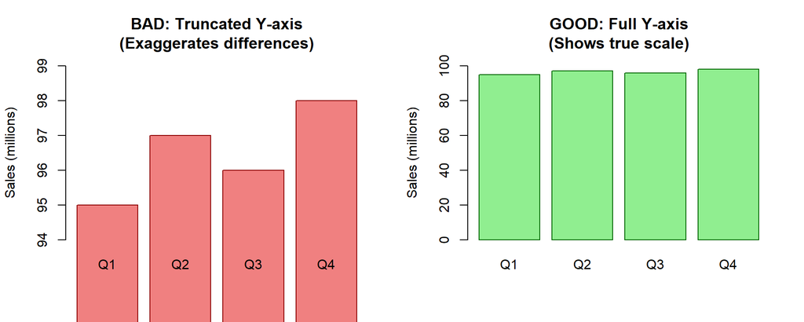

```r
# Example: Truncated Y-axis exaggerates differences
set.seed(seeds[2])
sales_data <- data.frame(
  Quarter = c("Q1", "Q2", "Q3", "Q4"),
  Sales = c(95, 97, 96, 98)
)

par(mfrow = c(1, 2))

# BAD: Truncated axis
barplot(sales_data$Sales, names.arg = sales_data$Quarter,
        main = "BAD: Truncated Y-axis\n(Exaggerates differences)",
        ylab = "Sales (millions)", ylim = c(94, 99),
        col = "lightcoral", border = "darkred")

# GOOD: Full scale
barplot(sales_data$Sales, names.arg = sales_data$Quarter,
        main = "GOOD: Full Y-axis\n(Shows true scale)",
        ylab = "Sales (millions)", ylim = c(0, 100),
        col = "lightgreen", border = "darkgreen")
```

```r
par(mfrow = c(1, 1))
```

**Interpretation:** The left plot (truncated Y-axis) makes Q4 sales appear dramatically higher than Q1, when in reality the difference is only 3% [1, Ch. 4].

**2. 3D Charts and Chartjunk**

Field et al. [1, Ch. 4] warn against unnecessary 3D effects, which: - Distort perception of magnitudes - Make precise value reading difficult - Add visual clutter without information

**3. Overlays and Pattern Confusion**

- Avoid overlapping bars with different patterns
- Use color sparingly and consistently
- Ensure sufficient contrast for accessibility

## 1.3 Programming Suggestion: Code Stacking

When building complex `ggplot2` visualizations, **stack your code** across multiple lines [1, Ch. 4]. This improves readability and makes troubleshooting easier.

```r
# BAD: Everything on one line (hard to read and debug)
ggplot(data, aes(x, y, color = group)) + geom_point() + geom_line() + xlab("X Label") + ylab("Y Label") + theme_minimal()

# GOOD: Stacked code (easy to read and modify)
ggplot(data, aes(x, y, color = group)) +
  geom_point() +
  geom_line() +
  xlab("X Label") +
  ylab("Y Label") +
  theme_minimal()
```

**Why this matters:** When you get an error, R will tell you which line failed. With stacked code, you can comment out layers one at a time to isolate the problem [1, Ch. 4].

# Part 2: The Grammar of Graphics and ggplot2

## 2.1 Understanding the Grammar of Graphics

**What is the grammar of graphics?** Wilkinson [3] introduced a systematic way to describe the components of a graph. Wickham [4] implemented this in `ggplot2`, which Field et al. [1, Ch. 4] recommend as the standard for R visualization.

### 2.1.1 Core Components

Every `ggplot2` graph has three essential components:

1. **Data**: The dataset you want to visualize
2. **Aesthetics (aes)**: Mappings from data variables to visual properties (x, y, color, size, shape)
3. **Geometries (geom)**: The type of plot (points, lines, bars, etc.)

```r
# Basic structure
ggplot(data = <DATA>,               # 1. Data
       aes(x = <X_VAR>,             # 2. Aesthetics
           y = <Y_VAR>,
           color = <COLOR_VAR>)) +
  geom_<TYPE>()                     # 3. Geometry
```

### 2.1.2 Layered Approach

`ggplot2` builds graphs in **layers** [1, Ch. 4]:

1. **Base layer**: Define data and aesthetics with `ggplot()`
2. **Geometry layers**: Add visual representations with `geom_*()`
3. **Statistics layers**: Add statistical transformations with `stat_*()`
4. **Scale layers**: Customize axes and legends with `scale_*()`
5. **Coordinate layers**: Adjust coordinate systems with `coord_*()`
6. **Theme layers**: Control non-data elements with `theme_*()`

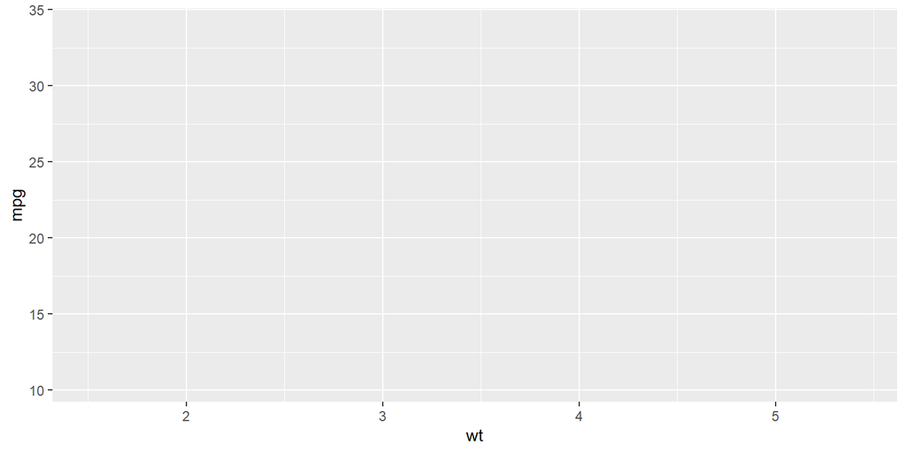

```r
# Demonstrate layered approach
data(mtcars)

# Start with base
p <- ggplot(mtcars, aes(x = wt, y = mpg))

# Layer 1: Just the base (empty plot)
p
```

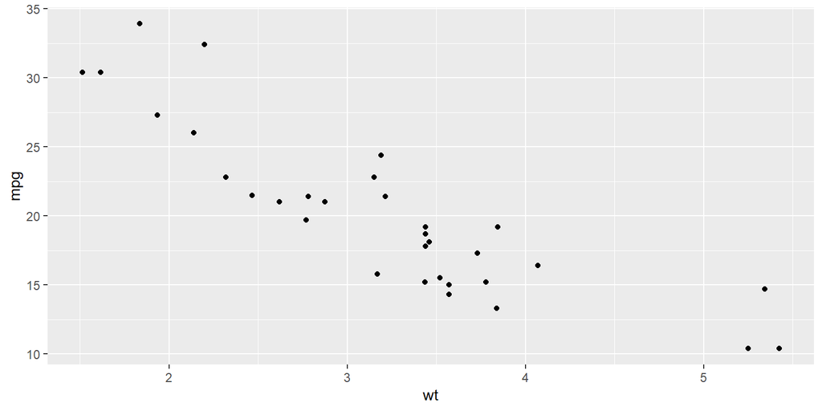

```r
# Layer 2: Add points
p + geom_point()
```

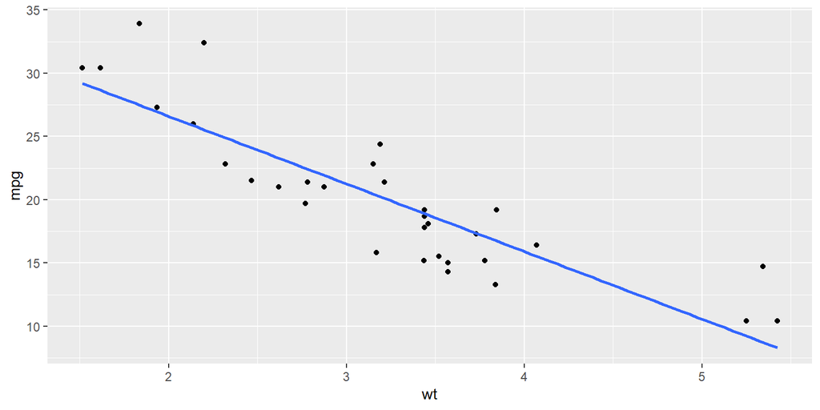

```r
# Layer 3: Add smooth line
p + geom_point() + geom_smooth(method = "lm", se = FALSE)
```

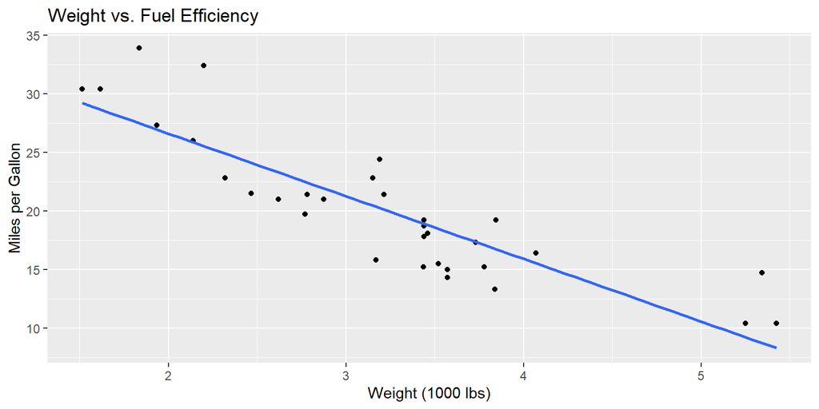

```r
# Layer 4: Add labels
p +
  geom_point() +
  geom_smooth(method = "lm", se = FALSE) +
  labs(title = "Weight vs. Fuel Efficiency",
       x = "Weight (1000 lbs)",
       y = "Miles per Gallon")
```

**Key insight [1, Ch. 4]:** By separating data, aesthetics, and geometries, `ggplot2` allows you to quickly try different visualizations of the same data by changing only the `geom_*()` layer.

## 2.2 Creating a Reusable Theme

Field et al. [1, Ch. 4] recommend creating a custom theme for consistency across all your plots.

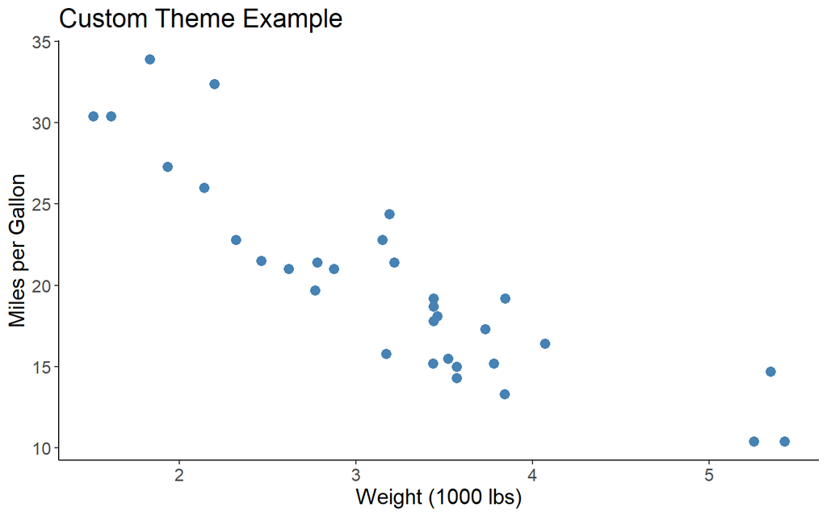

```r
# Create a clean, professional theme
cleanup <- theme(
  panel.grid.major = element_blank(),      # Remove major gridlines
  panel.grid.minor = element_blank(),      # Remove minor gridlines
  panel.background = element_blank(),      # Remove background
  axis.line.x = element_line(color = 'black'),  # Black x-axis
  axis.line.y = element_line(color = 'black'),  # Black y-axis
  legend.key = element_rect(fill = 'white'),    # White legend background
  text = element_text(size = 15)           # Larger text for readability
)

# Test the theme
ggplot(mtcars, aes(x = wt, y = mpg)) +
  geom_point(size = 3, color = "steelblue") +
  labs(title = "Custom Theme Example",
       x = "Weight (1000 lbs)",
       y = "Miles per Gallon") +
  cleanup
```

**Practical tip:** Save this `cleanup` theme in your R script and add it to every plot with `+ cleanup`. This ensures all your visualizations have a consistent, professional appearance [1, Ch. 4].

# Part 3: Histograms for Understanding Distributions

## 3.1 What is a Histogram?

**Definition [1, Ch. 4]:** A histogram plots: - **X-axis**: Continuous score bins - **Y-axis**: Frequency (count) of observations in each bin

**Why histograms matter:** They help you identify: 1. **Shape** of the distribution (normal, skewed, bimodal) 2. **Spread** or variation in scores 3. **Outliers** or unusual values 4. **Gaps** in the data

### 3.1.1 Example Dataset: Jiminy Cricket

Field et al. [1, Ch. 4] use a whimsical example to test the Disney philosophy: “Wishing upon a star makes all your dreams come true.”

**Study design:** - 250 participants randomly assigned to either: - **Wish upon a star** for 5 years - **Work as hard as they can** for 5 years - **Outcome:** Success measured on a 0–4 scale (0 = complete failure, 4 = complete success) - **Measurement:** Success assessed at baseline (pre) and after 5 years (post)

```r
# Create example data (simulating the Jiminy Cricket study)
set.seed(seeds[3])

cricket <- data.frame(
  ID = 1:250,
  Strategy = rep(c("Wish upon a star", "Work hard"), each = 125),
  Success_Pre = c(
    rnorm(125, mean = 2.0, sd = 0.8),  # Wish group baseline
    rnorm(125, mean = 2.0, sd = 0.8)   # Work group baseline
  ),
  Success_Post = c(
    rnorm(125, mean = 2.1, sd = 0.9),  # Wish group post (minimal change)
    rnorm(125, mean = 3.2, sd = 0.7)   # Work group post (substantial improvement)
  )
)

# Constrain to 0-4 scale
cricket$Success_Pre <- pmin(pmax(cricket$Success_Pre, 0), 4)
cricket$Success_Post <- pmin(pmax(cricket$Success_Post, 0), 4)

head(cricket) %>%
  kable(caption = "Jiminy Cricket Dataset (First 6 Rows)", digits = 2) %>%
  kable_styling(bootstrap_options = c("striped", "hover"), full_width = FALSE)
```

Jiminy Cricket Dataset (First 6 Rows)

| ID | Strategy | Success_Pre | Success_Post |
| --- | --- | --- | --- |
| 1 | Wish upon a star | 1.01 | 2.08 |
| 2 | Wish upon a star | 1.86 | 1.65 |
| 3 | Wish upon a star | 1.74 | 2.41 |
| 4 | Wish upon a star | 1.79 | 3.21 |
| 5 | Wish upon a star | 0.59 | 2.70 |
| 6 | Wish upon a star | 2.14 | 3.09 |

## 3.2 Building Histograms with ggplot2

### 3.2.1 Basic Histogram

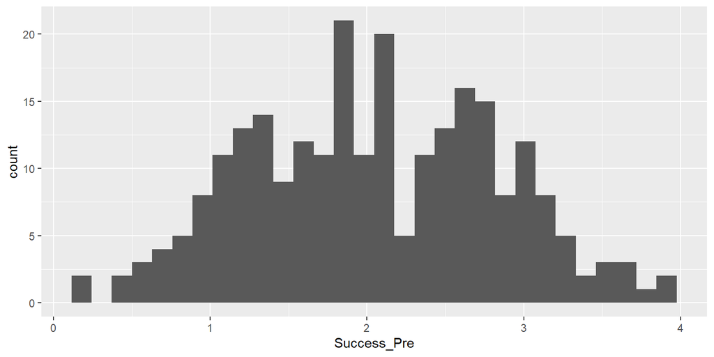

```r
# Step 1: Define the base plot
crickethist <- ggplot(data = cricket, aes(x = Success_Pre))

# Step 2: Add histogram layer
crickethist +
  geom_histogram()
```

### 3.2.2 Customizing Bin Width

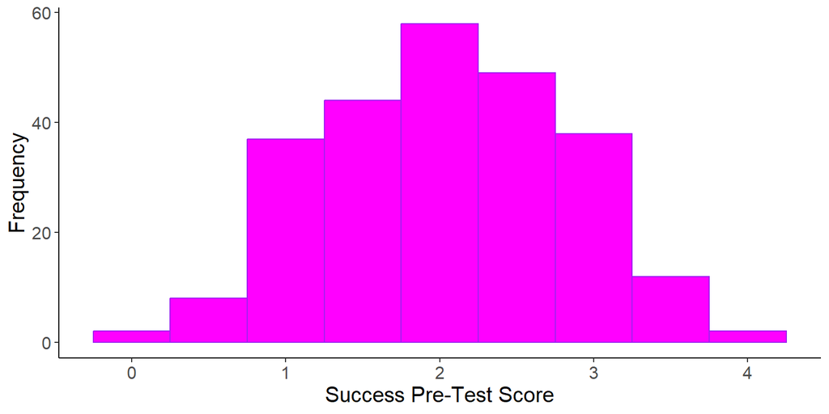

```r
# Better: Specify bin width explicitly
crickethist +
  geom_histogram(binwidth = 0.5, color = 'purple', fill = 'magenta') +
  xlab("Success Pre-Test Score") +
  ylab("Frequency") +
  cleanup
```

**Interpretation:** Most participants started with success scores around 2.0 (the middle of the scale), with roughly symmetric distribution [1, Ch. 4].

### 3.2.3 Comparing Distributions: Festival Hygiene Example

Field et al. [1, Ch. 4] use a memorable example: festival attendees rating their hygiene on each day (0 = “eau de toilet”, 4 = “eau de toilette”).

```r
# Create festival hygiene data
set.seed(seeds[4])

festival <- data.frame(
  ticknumb = 1:200,
  day1 = rnorm(200, mean = 3.5, sd = 0.5),
  day2 = rnorm(200, mean = 2.8, sd = 0.7),
  day3 = rnorm(200, mean = 1.8, sd = 0.9)
)

# Constrain to 0-4 scale
festival$day1 <- pmin(pmax(festival$day1, 0), 4)
festival$day2 <- pmin(pmax(festival$day2, 0), 4)
festival$day3 <- pmin(pmax(festival$day3, 0), 4)

head(festival) %>%
  kable(caption = "Festival Hygiene Dataset (First 6 Rows)", digits = 2) %>%
  kable_styling(bootstrap_options = c("striped", "hover"), full_width = FALSE)
```

Festival Hygiene Dataset (First 6 Rows)

| ticknumb | day1 | day2 | day3 |
| --- | --- | --- | --- |
| 1 | 2.93 | 3.22 | 1.87 |
| 2 | 3.11 | 3.22 | 1.07 |
| 3 | 4.00 | 1.41 | 2.82 |
| 4 | 2.73 | 3.59 | 2.67 |
| 5 | 3.39 | 1.40 | 2.45 |
| 6 | 4.00 | 2.10 | 0.83 |

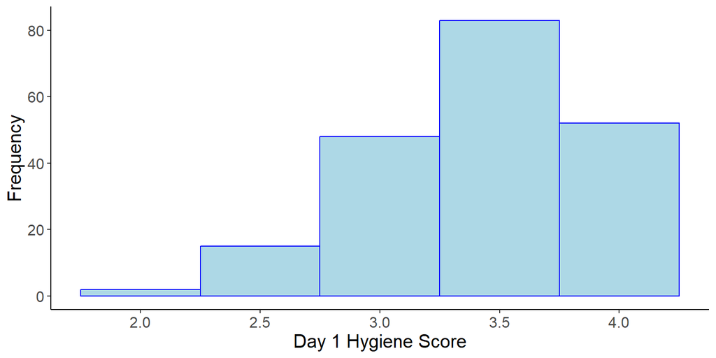

```r
# Histogram of Day 1 hygiene
festivalhist <- ggplot(data = festival, aes(x = day1))

festivalhist +
  geom_histogram(binwidth = 0.5, color = 'blue', fill = 'lightblue') +
  xlab("Day 1 Hygiene Score") +
  ylab("Frequency") +
  cleanup
```

**Interpretation:** On Day 1, most festival-goers rated their hygiene highly (scores around 3.5), suggesting they arrived clean [1, Ch. 4].

### 3.2.4 Overlaying Density Curves

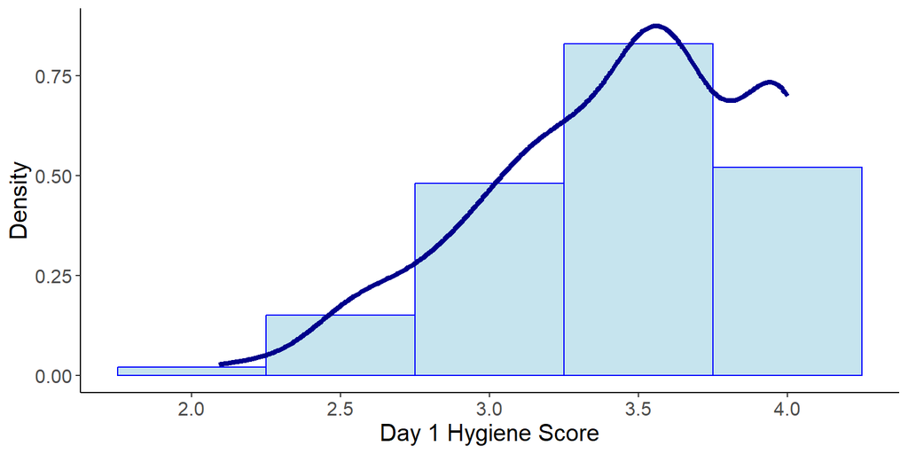

```r
# Add density curve to see distribution shape more clearly
festivalhist +
  geom_histogram(aes(y = ..density..), binwidth = 0.5,
                 color = 'blue', fill = 'lightblue', alpha = 0.7) +
  geom_density(color = 'darkblue', linewidth = 1.5) +
  xlab("Day 1 Hygiene Score") +
  ylab("Density") +
  cleanup
```

**Why density curves?** They smooth out the histogram’s jaggedness and make it easier to assess normality [1, Ch. 4].

# Part 4: Scatterplots for Exploring Relationships

## 4.1 What is a Scatterplot?

**Definition [1, Ch. 4]:** A scatterplot displays: - **X-axis**: One continuous variable (predictor) - **Y-axis**: Another continuous variable (outcome) - **Points**: Each observation plotted at (x, y) coordinates

**Why scatterplots matter:** They reveal: 1. **Direction** of relationship (positive, negative, none) 2. **Strength** of relationship (tight cluster vs. wide scatter) 3. **Form** of relationship (linear, curved, no pattern) 4. **Outliers** that might distort correlations or regressions

## 4.2 Example Dataset: Exam Anxiety

Field et al. [1, Ch. 4] use a dataset of 103 students who rated their exam anxiety, time spent revising, exam performance, and gender.

```r
# Create exam anxiety dataset
set.seed(seeds[5])

exam <- data.frame(
  Code = 1:103,
  Revise = runif(103, min = 5, max = 30),  # Hours of revision
  Exam = rnorm(103, mean = 60, sd = 15),   # Exam score
  Anxiety = rnorm(103, mean = 50, sd = 20), # Anxiety score
  Gender = sample(1:2, 103, replace = TRUE)
)

# Create negative correlation between anxiety and exam score
exam$Exam <- 80 - 0.4 * exam$Anxiety + rnorm(103, mean = 0, sd = 10)
exam$Exam <- pmin(pmax(exam$Exam, 0), 100)  # Constrain to 0-100

# Factor gender
exam$Gender <- factor(exam$Gender, levels = c(1, 2), labels = c("Male", "Female"))

head(exam) %>%
  kable(caption = "Exam Anxiety Dataset (First 6 Rows)", digits = 1) %>%
  kable_styling(bootstrap_options = c("striped", "hover"), full_width = FALSE)
```

Exam Anxiety Dataset (First 6 Rows)

| Code | Revise | Exam | Anxiety | Gender |
| --- | --- | --- | --- | --- |
| 1 | 25.3 | 62.0 | 60.7 | Female |
| 2 | 11.2 | 52.4 | 54.8 | Female |
| 3 | 20.8 | 69.6 | 36.8 | Female |
| 4 | 14.0 | 74.7 | 8.1 | Female |
| 5 | 17.3 | 60.9 | 45.1 | Male |
| 6 | 29.8 | 55.6 | 74.4 | Male |

## 4.3 Simple Scatterplot

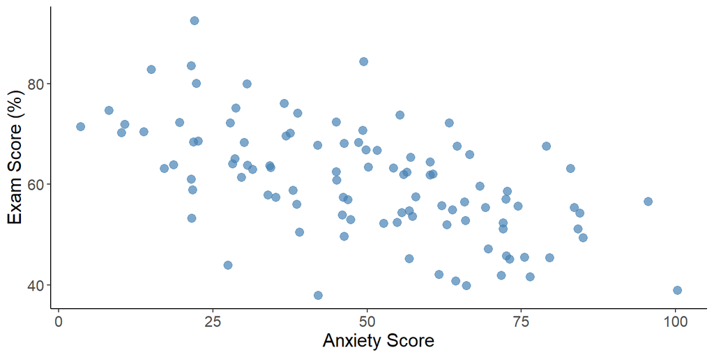

```r
# Basic scatterplot
scatter <- ggplot(exam, aes(x = Anxiety, y = Exam))

scatter +
  geom_point(size = 3, color = "steelblue", alpha = 0.7) +
  xlab("Anxiety Score") +
  ylab("Exam Score (%)") +
  cleanup
```

**Interpretation:** There appears to be a **negative relationship**—as anxiety increases, exam scores tend to decrease [1, Ch. 4].

## 4.4 Adding a Regression Line

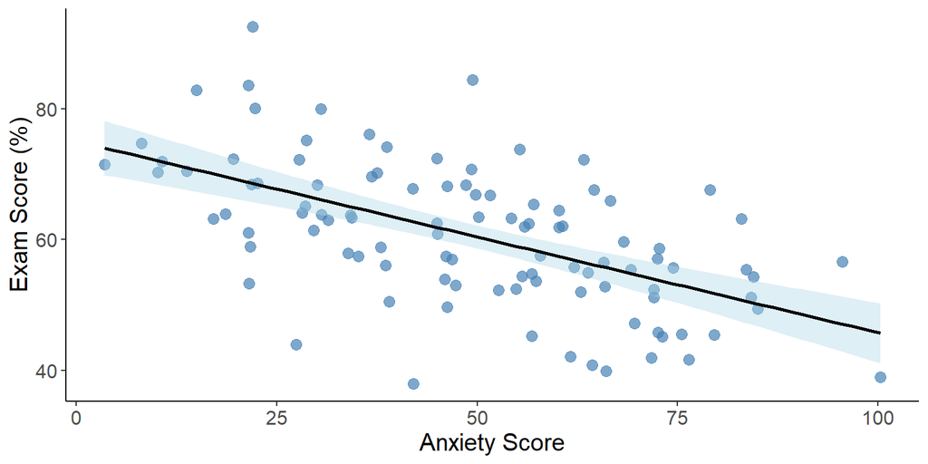

```r
# Add linear regression line with confidence band
scatter +
  geom_point(size = 3, color = "steelblue", alpha = 0.7) +
  geom_smooth(method = 'lm', formula = y ~ x,
              color = 'black', fill = 'lightblue') +
  xlab('Anxiety Score') +
  ylab('Exam Score (%)') +
  cleanup
```

**Interpretation:** The regression line confirms the negative trend. The shaded band shows the 95% confidence interval—wider at the extremes where we have fewer data points [1, Ch. 4].

## 4.5 Grouped Scatterplot

**Question:** Does the anxiety-performance relationship differ by gender?

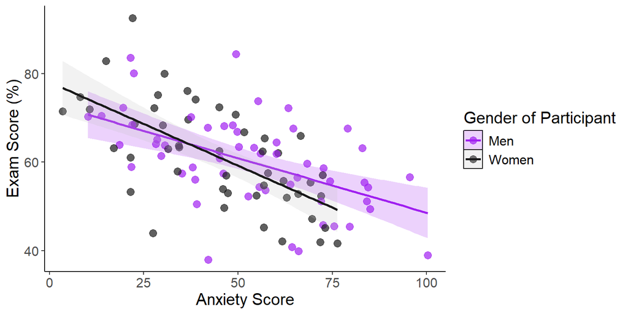

```r
# Scatterplot with groups
scatter2 <- ggplot(exam, aes(x = Anxiety, y = Exam,
                             color = Gender, fill = Gender))

scatter2 +
  geom_point(size = 3, alpha = 0.7) +
  geom_smooth(method = "lm", formula = y ~ x, alpha = 0.2) +
  xlab("Anxiety Score") +
  ylab("Exam Score (%)") +
  cleanup +
  scale_fill_manual(name = "Gender of Participant",
                    labels = c("Men", "Women"),
                    values = c("purple", "grey")) +
  scale_color_manual(name = "Gender of Participant",
                     labels = c("Men", "Women"),
                     values = c("purple", "grey10"))
```

## 4.6 Scatterplot Matrix with GGally

For exploring multiple relationships simultaneously, Field et al. [1, Ch. 4] recommend scatterplot matrices.

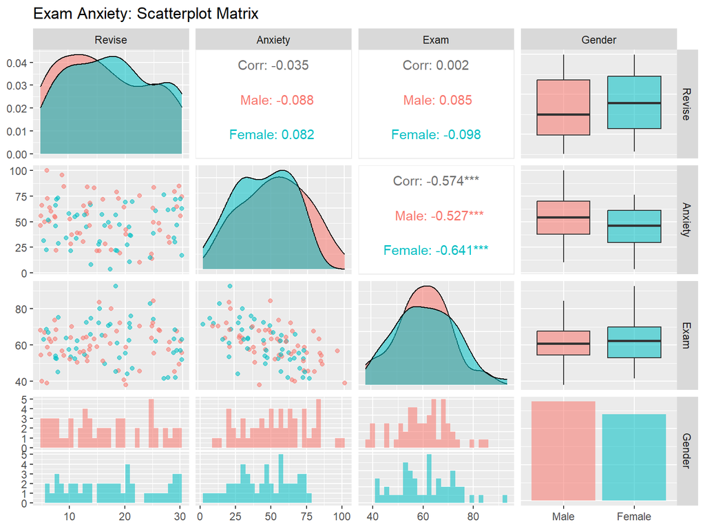

```r
library(GGally)

ggpairs(data = exam[, c("Revise", "Anxiety", "Exam", "Gender")],
        title = "Exam Anxiety: Scatterplot Matrix",
        mapping = aes(color = Gender, alpha = 0.5))
```

**Interpretation:** - **Diagonal**: Distributions of each variable by gender - **Lower triangle**: Scatterplots showing bivariate relationships - **Upper triangle**: Correlation coefficients

# Part 5: Data Reshaping for Visualization

## 5.1 Wide vs. Long Format

**Wide format:** Each participant gets one row; repeated measures are in separate columns [1, Ch. 4].

**Long format:** Each measurement gets one row; a variable indicates which measure it is [1, Ch. 4].

```r
# Wide format example
wide_data <- data.frame(
  ID = 1:5,
  Baseline = c(10, 12, 11, 13, 10),
  Month_6 = c(15, 17, 14, 18, 16),
  Month_12 = c(20, 22, 19, 23, 21)
)

wide_data %>%
  kable(caption = "Wide Format: One Row per Participant") %>%
  kable_styling(bootstrap_options = c("striped", "hover"), full_width = FALSE)
```

Wide Format: One Row per Participant

| ID | Baseline | Month_6 | Month_12 |
| --- | --- | --- | --- |
| 1 | 10 | 15 | 20 |
| 2 | 12 | 17 | 22 |
| 3 | 11 | 14 | 19 |
| 4 | 13 | 18 | 23 |
| 5 | 10 | 16 | 21 |

```r
# Convert to long format
long_data <- wide_data %>%
  pivot_longer(cols = c(Baseline, Month_6, Month_12),
               names_to = "Time",
               values_to = "Score")

long_data %>%
  head(10) %>%
  kable(caption = "Long Format: One Row per Measurement") %>%
  kable_styling(bootstrap_options = c("striped", "hover"), full_width = FALSE)
```

Long Format: One Row per Measurement

| ID | Time | Score |
| --- | --- | --- |
| 1 | Baseline | 10 |
| 1 | Month_6 | 15 |
| 1 | Month_12 | 20 |
| 2 | Baseline | 12 |
| 2 | Month_6 | 17 |
| 2 | Month_12 | 22 |
| 3 | Baseline | 11 |
| 3 | Month_6 | 14 |
| 3 | Month_12 | 19 |
| 4 | Baseline | 13 |

**Why reshape?** `ggplot2` requires long format for most visualizations because it maps variables to aesthetics—you need a single column for the outcome and a factor column to indicate groups [1, Ch. 4].

## 5.2 Reshaping the Jiminy Cricket Data

```r
# Original cricket data is wide
head(cricket, 3)
```

|  | ID | Strategy | Success_Pre | Success_Post |
| --- | --- | --- | --- | --- |
| 1 | 1 | Wish upon a star | 1.009296 | 2.080064 |
| 2 | 2 | Wish upon a star | 1.855181 | 1.647600 |
| 3 | 3 | Wish upon a star | 1.736024 | 2.406613 |

```r
# Reshape to long format
longcricket <- cricket %>%
  pivot_longer(cols = c(Success_Pre, Success_Post),
               names_to = "Time",
               values_to = "Score") %>%
  mutate(Time = factor(Time,
                       levels = c("Success_Pre", "Success_Post"),
                       labels = c("Baseline", "5 Years")))

longcricket %>%
  head(10) %>%
  kable(caption = "Long Format Cricket Data", digits = 2) %>%
  kable_styling(bootstrap_options = c("striped", "hover"), full_width = FALSE)
```

Long Format Cricket Data

| ID | Strategy | Time | Score |
| --- | --- | --- | --- |
| 1 | Wish upon a star | Baseline | 1.01 |
| 1 | Wish upon a star | 5 Years | 2.08 |
| 2 | Wish upon a star | Baseline | 1.86 |
| 2 | Wish upon a star | 5 Years | 1.65 |
| 3 | Wish upon a star | Baseline | 1.74 |
| 3 | Wish upon a star | 5 Years | 2.41 |
| 4 | Wish upon a star | Baseline | 1.79 |
| 4 | Wish upon a star | 5 Years | 3.21 |
| 5 | Wish upon a star | Baseline | 0.59 |
| 5 | Wish upon a star | 5 Years | 2.70 |

# Part 6: Bar Graphs for Comparing Group Means

## 6.1 What is a Bar Graph?

**Definition [1, Ch. 4]:** A bar graph displays: - **X-axis**: Categorical groups - **Y-axis**: Mean of a continuous outcome - **Bars**: Height represents the group mean - **Error bars**: Show precision of the mean (confidence interval, standard error, or standard deviation)

**Why bar graphs matter:** They allow quick visual comparison of means across groups, with error bars indicating whether differences are likely meaningful [1, Ch. 4].

### 6.1.1 Types of Error Bars

Field et al. [1, Ch. 4] discuss three common types:

1. **Standard Deviation (SD)**: Shows spread of individual scores
2. **Standard Error (SE)**: Shows precision of the mean estimate
3. **Confidence Interval (CI)**: Shows range likely containing the true population mean

**Recommendation:** Use 95% confidence intervals for inferential purposes—non-overlapping CIs suggest significant differences [1, Ch. 4].

## 6.2 Example: Chick Flick Study

Field et al. [1, Ch. 4] describe a study testing whether “chick flicks” exist:

**Study design:** - 20 men and 20 women randomly assigned to watch either: - **Bridget Jones’s Diary** (presumed “chick flick”) - **Memento** (control movie) - **Outcome:** Physiological arousal (higher = more enjoyment)

```r
# Create chick flick dataset
set.seed(seeds[6])

chickflick <- data.frame(
  gender = rep(1:2, each = 20),
  film = rep(rep(1:2, each = 10), 2),
  arousal = c(
    rnorm(10, mean = 15, sd = 5),  # Men watching Bridget Jones
    rnorm(10, mean = 18, sd = 5),  # Men watching Memento
    rnorm(10, mean = 30, sd = 6),  # Women watching Bridget Jones
    rnorm(10, mean = 17, sd = 5)   # Women watching Memento
  )
)

# Factor variables
chickflick$gender <- factor(chickflick$gender,
                            levels = c(1, 2),
                            labels = c("Male", "Female"))

chickflick$film <- factor(chickflick$film,
                         levels = c(1, 2),
                         labels = c("Bridget Jones", "Memento"))

head(chickflick) %>%
  kable(caption = "Chick Flick Dataset (First 6 Rows)", digits = 1) %>%
  kable_styling(bootstrap_options = c("striped", "hover"), full_width = FALSE)
```

Chick Flick Dataset (First 6 Rows)

| gender | film | arousal |
| --- | --- | --- |
| Male | Bridget Jones | 17.0 |
| Male | Bridget Jones | 13.9 |
| Male | Bridget Jones | 15.4 |
| Male | Bridget Jones | 10.2 |
| Male | Bridget Jones | 13.2 |
| Male | Bridget Jones | 26.8 |

## 6.3 Bar Chart: One Independent Variable

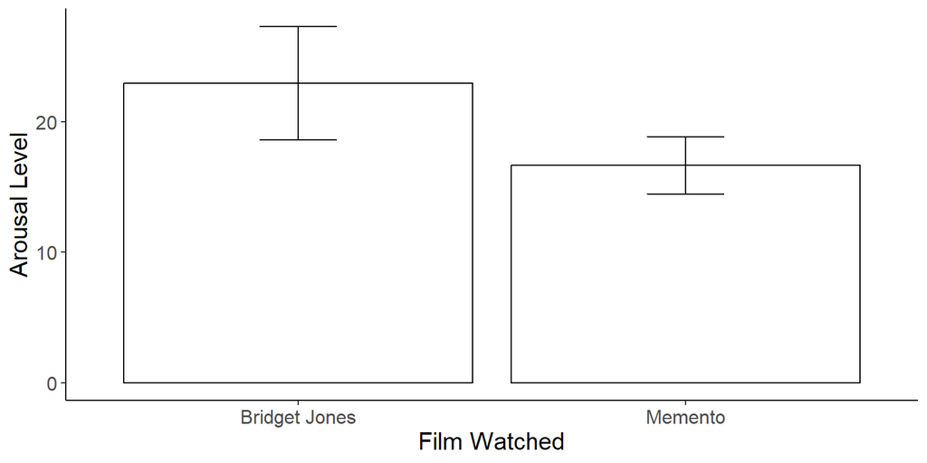

```r
# Bar chart showing mean arousal by film
chickbar <- ggplot(chickflick, aes(x = film, y = arousal))

chickbar +
  stat_summary(fun = mean,
               geom = "bar",
               fill = "White",
               color = "Black") +
  stat_summary(fun.data = mean_cl_normal,
               geom = "errorbar",
               width = 0.2) +
  xlab("Film Watched") +
  ylab("Arousal Level") +
  cleanup
```

## 6.4 Bar Chart: Two Independent Variables

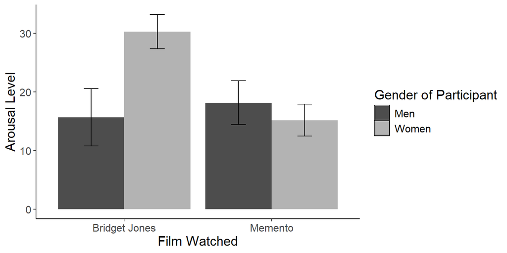

```r
# Bar chart with gender as second factor
chickbar2 <- ggplot(chickflick, aes(x = film, y = arousal, fill = gender))

chickbar2 +
  stat_summary(fun = mean,
               geom = "bar",
               position = "dodge") +
  stat_summary(fun.data = mean_cl_normal,
               geom = "errorbar",
               position = position_dodge(width = 0.90),
               width = 0.2) +
  xlab("Film Watched") +
  ylab("Arousal Level") +
  cleanup +
  scale_fill_manual(name = "Gender of Participant",
                    labels = c("Men", "Women"),
                    values = c("gray30", "gray70"))
```

**Interpretation:** Now the pattern is clear! Women showed much higher arousal watching Bridget Jones than Memento, while men showed similar arousal for both films. This supports the “chick flick” hypothesis [1, Ch. 4].

**Key insight:** The interaction between gender and film was hidden when we ignored gender. This demonstrates why **visualizing data by subgroups** is crucial [1, Ch. 4].

# Part 7: Line Graphs for Longitudinal Data

## 7.1 When to Use Line Graphs

Field et al. [1, Ch. 4] recommend line graphs when:

1. **X-axis is continuous or ordered** (time, dose, age)
2. **Repeated measures** or longitudinal data
3. **Tracking change** over time or conditions

**Why lines instead of bars?** Lines emphasize continuity and trends, making them ideal for time-series or dose-response data [1, Ch. 4].

## 7.2 Example: Hiccup Cures

Field et al. [1, Ch. 4] describe a study testing four hiccup cures:

**Study design:** - 15 participants tried four interventions: - **Baseline** (no treatment) - **Tongue pulling** for 1 minute - **Carotid artery massage** - **Digital rectal massage** (yes, really!) - **Outcome:** Number of hiccups in the minute after each procedure

```r
# Create hiccups dataset
set.seed(seeds[7])

hiccups <- data.frame(
  Participant = 1:15,
  Baseline = rpois(15, lambda = 15),
  Tongue = rpois(15, lambda = 12),
  Carotid = rpois(15, lambda = 8),
  Other = rpois(15, lambda = 5)
)

head(hiccups) %>%
  kable(caption = "Hiccups Dataset (First 6 Rows)") %>%
  kable_styling(bootstrap_options = c("striped", "hover"), full_width = FALSE)
```

Hiccups Dataset (First 6 Rows)

| Participant | Baseline | Tongue | Carotid | Other |
| --- | --- | --- | --- | --- |
| 1 | 15 | 9 | 6 | 4 |
| 2 | 20 | 17 | 8 | 4 |
| 3 | 17 | 10 | 6 | 4 |
| 4 | 12 | 17 | 9 | 6 |
| 5 | 16 | 7 | 10 | 4 |
| 6 | 12 | 10 | 7 | 5 |

## 7.3 Reshaping for Line Graphs

```r
# Reshape to long format
longhiccups <- hiccups %>%
  pivot_longer(cols = c(Baseline, Tongue, Carotid, Other),
               names_to = "Intervention",
               values_to = "Hiccups") %>%
  mutate(Intervention = factor(Intervention,
                               levels = c("Baseline", "Tongue", "Carotid", "Other")))

longhiccups %>%
  head(10) %>%
  kable(caption = "Long Format Hiccups Data") %>%
  kable_styling(bootstrap_options = c("striped", "hover"), full_width = FALSE)
```

Long Format Hiccups Data

| Participant | Intervention | Hiccups |
| --- | --- | --- |
| 1 | Baseline | 15 |
| 1 | Tongue | 9 |
| 1 | Carotid | 6 |
| 1 | Other | 4 |
| 2 | Baseline | 20 |
| 2 | Tongue | 17 |
| 2 | Carotid | 8 |
| 2 | Other | 4 |
| 3 | Baseline | 17 |
| 3 | Tongue | 10 |

## 7.4 Line Graph: One Independent Variable

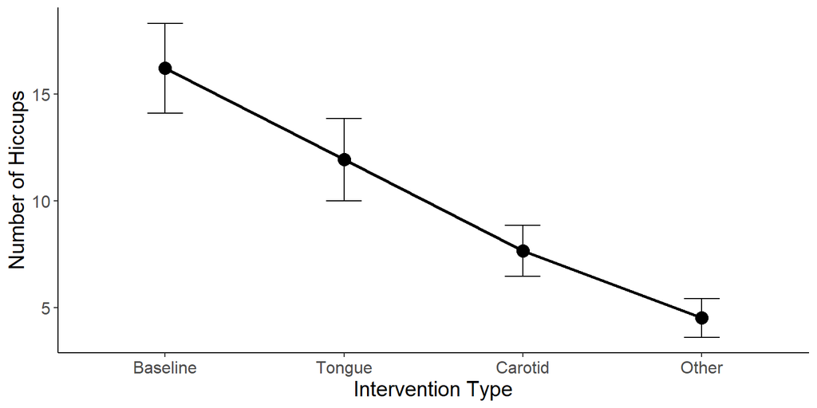

```r
# Line graph of mean hiccups by intervention
hiccupline <- ggplot(longhiccups, aes(x = Intervention, y = Hiccups))

hiccupline +
  stat_summary(fun = mean, geom = "point", size = 4) +
  stat_summary(fun = mean, geom = "line", aes(group = 1), linewidth = 1) +
  stat_summary(fun.data = mean_cl_normal, geom = "errorbar", width = 0.2) +
  xlab("Intervention Type") +
  ylab("Number of Hiccups") +
  cleanup
```

**Interpretation:** All three interventions reduced hiccups compared to baseline, with the “Other” intervention (digital rectal massage) being most effective. The `aes(group = 1)` tells `ggplot2` to connect all points with a single line [1, Ch. 4].

## 7.5 Example: Text Messaging and Grammar

Field et al. [1, Ch. 4] describe a study testing whether text messaging harms grammar:

**Study design:** - 50 children randomly assigned to: - **Text messaging allowed** (n = 25) - **Text messaging forbidden** (n = 25) - **Outcome:** Grammar test score (% correct) at baseline and 6 months

```r
# Create texting dataset
set.seed(seeds[8])

texting <- data.frame(
  Group = rep(1:2, each = 25),
  Baseline = c(
    rnorm(25, mean = 65, sd = 10),  # Texting allowed
    rnorm(25, mean = 65, sd = 10)   # No texting
  ),
  Six_months = c(
    rnorm(25, mean = 60, sd = 12),  # Texting allowed (decline)
    rnorm(25, mean = 70, sd = 10)   # No texting (improvement)
  )
)

# Factor group
texting$Group <- factor(texting$Group,
                       levels = c(1, 2),
                       labels = c("Texting Allowed", "No Texting Allowed"))

head(texting) %>%
  kable(caption = "Texting Dataset (First 6 Rows)", digits = 1) %>%
  kable_styling(bootstrap_options = c("striped", "hover"), full_width = FALSE)
```

Texting Dataset (First 6 Rows)

| Group | Baseline | Six_months |
| --- | --- | --- |
| Texting Allowed | 67.2 | 76.0 |
| Texting Allowed | 64.8 | 67.8 |
| Texting Allowed | 57.0 | 63.5 |
| Texting Allowed | 89.0 | 64.7 |
| Texting Allowed | 68.4 | 49.2 |
| Texting Allowed | 43.4 | 45.7 |

## 7.6 Reshaping for Two-Factor Line Graphs

```r
# Reshape to long format
longtexting <- texting %>%
  pivot_longer(cols = c(Baseline, Six_months),
               names_to = "Time",
               values_to = "Grammar_Score") %>%
  mutate(Time = factor(Time,
                      levels = c("Baseline", "Six_months"),
                      labels = c("Baseline", "Six Months")))

longtexting %>%
  head(10) %>%
  kable(caption = "Long Format Texting Data", digits = 1) %>%
  kable_styling(bootstrap_options = c("striped", "hover"), full_width = FALSE)
```

Long Format Texting Data

| Group | Time | Grammar_Score |
| --- | --- | --- |
| Texting Allowed | Baseline | 67.2 |
| Texting Allowed | Six Months | 76.0 |
| Texting Allowed | Baseline | 64.8 |
| Texting Allowed | Six Months | 67.8 |
| Texting Allowed | Baseline | 57.0 |
| Texting Allowed | Six Months | 63.5 |
| Texting Allowed | Baseline | 89.0 |
| Texting Allowed | Six Months | 64.7 |
| Texting Allowed | Baseline | 68.4 |
| Texting Allowed | Six Months | 49.2 |

## 7.7 Line Graph: Two Independent Variables

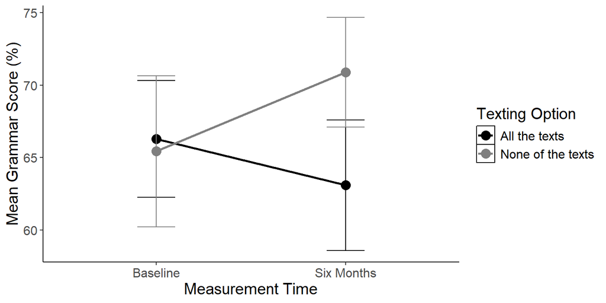

```r
# Line graph with two factors
textline <- ggplot(longtexting, aes(x = Time, y = Grammar_Score, color = Group))

textline +
  stat_summary(fun = mean, geom = "point", size = 4) +
  stat_summary(fun = mean, geom = "line", aes(group = Group), linewidth = 1) +
  stat_summary(fun.data = mean_cl_normal, geom = "errorbar", width = 0.2) +
  xlab("Measurement Time") +
  ylab("Mean Grammar Score (%)") +
  cleanup +
  scale_color_manual(name = "Texting Option",
                     labels = c("All the texts", "None of the texts"),
                     values = c("black", "grey50")) +
  scale_x_discrete(labels = c("Baseline", "Six Months"))
```

**Interpretation:** This reveals a clear **interaction effect** [1, Ch. 4]: - **Texting allowed group**: Grammar scores declined from baseline to 6 months - **No texting group**: Grammar scores improved over the same period

# Part 8: Advanced Customization and Best Practices

## 8.1 Color Scales and Accessibility

Field et al. [1, Ch. 4] emphasize choosing colors that: 1. Are distinguishable by colorblind individuals 2. Print well in grayscale 3. Have sufficient contrast

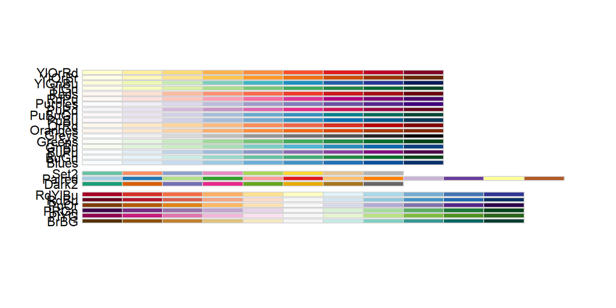

```r
# Compare color schemes
library(RColorBrewer)

# Display colorblind-friendly palettes
display.brewer.all(colorblindFriendly = TRUE)
```

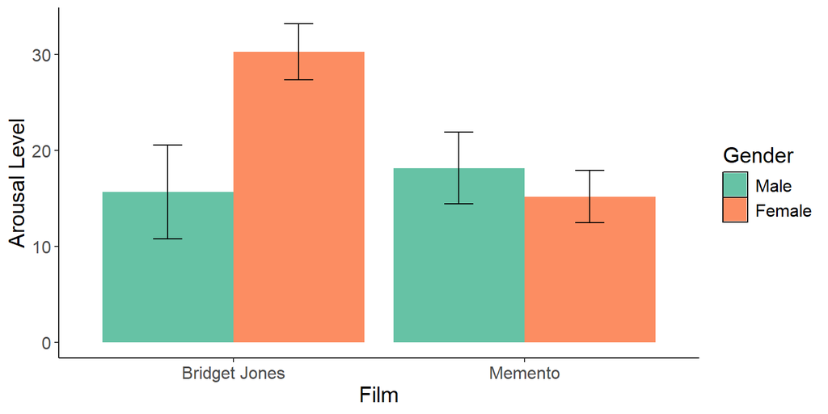

```r
# Example with colorblind-friendly palette
ggplot(chickflick, aes(x = film, y = arousal, fill = gender)) +
  stat_summary(fun = mean, geom = "bar", position = "dodge") +
  stat_summary(fun.data = mean_cl_normal, geom = "errorbar",
               position = position_dodge(0.9), width = 0.2) +
  scale_fill_brewer(palette = "Set2", name = "Gender") +
  xlab("Film") +
  ylab("Arousal Level") +
  cleanup
```

## 8.2 Faceting for Small Multiples

**What is faceting?** Creating multiple subplots for different groups [1, Ch. 4].

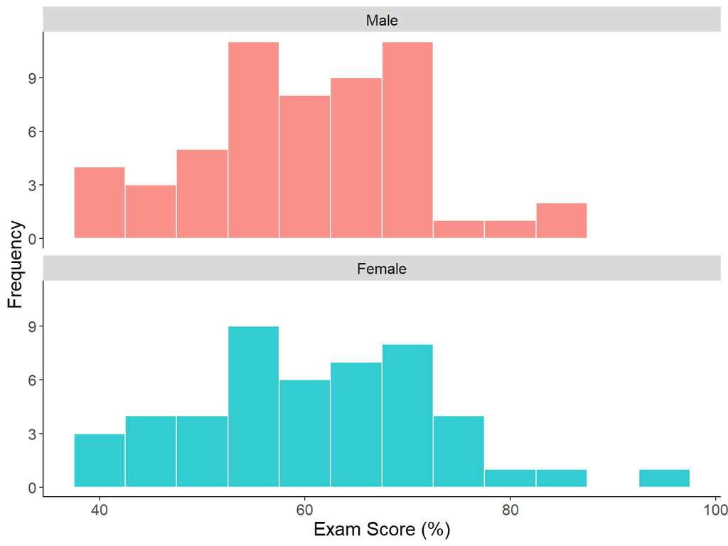

```r
# Faceted histogram by gender
ggplot(exam, aes(x = Exam, fill = Gender)) +
  geom_histogram(binwidth = 5, color = "white", alpha = 0.8) +
  facet_wrap(~ Gender, ncol = 1) +
  xlab("Exam Score (%)") +
  ylab("Frequency") +
  cleanup +
  theme(legend.position = "none")
```

**Why faceting?** It avoids overplotting and makes comparisons clearer when you have many groups [1, Ch. 4].

## 8.3 Saving High-Quality Figures

```r
# Save as PNG (for presentations)
ggsave("figure1.png", width = 8, height = 5, dpi = 300)

# Save as PDF (for publications)
ggsave("figure1.pdf", width = 8, height = 5)

# Save as SVG (for vector editing)
ggsave("figure1.svg", width = 8, height = 5)
```

**Recommendation [1, Ch. 4]:** Use 300 dpi for print publications, 150 dpi for web/presentations.

## 8.4 Annotating Plots

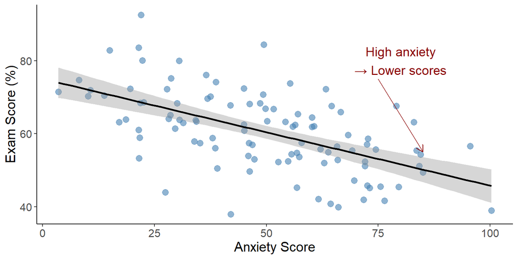

```r
# Add annotations to highlight key findings
ggplot(exam, aes(x = Anxiety, y = Exam)) +
  geom_point(size = 3, alpha = 0.6, color = "steelblue") +
  geom_smooth(method = "lm", se = TRUE, color = "black") +
  annotate("text", x = 80, y = 80,
           label = "High anxiety\n→ Lower scores",
           size = 5, color = "darkred") +
  annotate("segment", x = 75, xend = 85, y = 75, yend = 55,
           arrow = arrow(length = unit(0.3, "cm")), color = "darkred") +
  xlab("Anxiety Score") +
  ylab("Exam Score (%)") +
  cleanup
```

# Part 9: Summary and Best Practices

## 9.1 Visualization Workflow Checklist

Field et al. [1, Ch. 4] recommend this workflow:

Recommended Visualization Workflow [1, Ch. 4]

Key_Function

1

Explore data with summary statistics

summary(), str(), head()

2

Check for missing values and outliers

is.na(), boxplot()

3

Choose appropriate plot type for your question

4

Create basic plot with ggplot2

ggplot(data, aes(…))

5

Add layers (error bars, regression lines, etc.)

- geom_*(), + stat_summary()

6

Customize aesthetics (colors, labels, theme)

- scale_*(), + labs(), + theme()

7

Check assumptions visually (normality, linearity)

Q-Q plots, residual plots

8

Save high-quality figure with ggsave()

ggsave(‘file.png’, dpi=300)

## 9.2 Plot Type Selection Guide

Plot Type Selection Guide [1, Ch. 4]

| Data_Structure | Research_Question | Recommended_Plot | ggplot2_Geom |
| --- | --- | --- | --- |
| One continuous variable | What is the distribution shape? | Histogram + density curve | geom_histogram() + geom_density() |
| One continuous variable | Are there outliers? | Boxplot | geom_boxplot() |
| One categorical variable | What are the frequencies? | Bar chart (counts) | geom_bar() |
| Two continuous variables | Is there a relationship? | Scatterplot ± regression line | geom_point() + geom_smooth() |
| Continuous outcome by categorical group | Do group means differ? | Bar chart with error bars | stat_summary(geom=‘bar’) |
| Continuous outcome by categorical group | Do group means differ? | Boxplot or violin plot | geom_boxplot() / geom_violin() |
| Repeated measures / time series | How do values change over time? | Line graph with error bars | stat_summary(geom=‘line’) |
| Multiple continuous variables | What are pairwise relationships? | Scatterplot matrix (GGally::ggpairs) | GGally::ggpairs() |

## 9.3 Common ggplot2 Mistakes and Fixes

```r
# ❌ MISTAKE 1: Forgetting aes() for variable mappings
ggplot(data, x = variable, y = variable2) + geom_point()
# ✅ FIX: Wrap variables in aes()
ggplot(data, aes(x = variable, y = variable2)) + geom_point()

# ❌ MISTAKE 2: Using = instead of == in filters
data %>% filter(group = "A")
# ✅ FIX: Use == for logical comparison
data %>% filter(group == "A")

# ❌ MISTAKE 3: Forgetting group aesthetic for line plots
ggplot(data, aes(x = time, y = score, color = group)) +
  stat_summary(fun = mean, geom = "line")
# ✅ FIX: Add group aesthetic
ggplot(data, aes(x = time, y = score, color = group)) +
  stat_summary(fun = mean, geom = "line", aes(group = group))

# ❌ MISTAKE 4: Not reshaping data to long format
# Wide format won't work for most ggplot2 visualizations
# ✅ FIX: Use pivot_longer() or melt()
long_data <- wide_data %>%
  pivot_longer(cols = c(var1, var2), names_to = "variable", values_to = "value")
```

## 9.4 Key Takeaways

Based on Field et al. [1, Ch. 4]:

1. **Always plot your data first** before running statistical tests
2. **Choose plot types** that match your data structure and research question
3. **Use error bars** (preferably 95% CIs) to show precision of estimates
4. **Avoid chartjunk** (3D effects, excessive colors, decorative elements)
5. **Reshape data to long format** for most ggplot2 visualizations
6. **Stack your code** across multiple lines for readability
7. **Create a custom theme** for consistency across all plots
8. **Check colorblind accessibility** and grayscale printing
9. **Save high-resolution figures** (300 dpi for print, 150 dpi for web)
10. **Annotate key findings** to guide reader interpretation

# Part 10: Practice Exercises

## Exercise 1: Histogram and Distribution Assessment

Using the `mtcars` dataset:

1. Create a histogram of `mpg` with appropriate bin width
2. Add a density curve overlay
3. Assess whether the distribution is approximately normal
4. Calculate and report skewness and kurtosis

```r
# Your code here
library(moments)

# Histogram with density
ggplot(mtcars, aes(x = mpg)) +
  geom_histogram(aes(y = ..density..), binwidth = 2,
                 fill = "lightblue", color = "white") +
  geom_density(color = "darkblue", linewidth = 1.5) +
  xlab("Miles per Gallon") +
  ylab("Density") +
  cleanup

# Distribution statistics
cat("Skewness:", skewness(mtcars$mpg), "\n")
cat("Kurtosis:", kurtosis(mtcars$mpg), "\n")
```

## Exercise 2: Scatterplot with Groups

Using the `iris` dataset:

1. Create a scatterplot of `Sepal.Length` vs. `Sepal.Width`
2. Color points by `Species`
3. Add separate regression lines for each species
4. Interpret whether the relationship differs by species

```r
# Your code here
ggplot(iris, aes(x = Sepal.Length, y = Sepal.Width, color = Species)) +
  geom_point(size = 3, alpha = 0.7) +
  geom_smooth(method = "lm", se = TRUE) +
  xlab("Sepal Length (cm)") +
  ylab("Sepal Width (cm)") +
  cleanup
```

## Exercise 3: Bar Chart with Error Bars

Using the `chickflick` dataset:

1. Create a bar chart showing mean arousal by film
2. Add 95% confidence interval error bars
3. Customize the x-axis labels to be more descriptive
4. Apply a professional theme

```r
# Your code here
ggplot(chickflick, aes(x = film, y = arousal)) +
  stat_summary(fun = mean, geom = "bar", fill = "steelblue") +
  stat_summary(fun.data = mean_cl_normal, geom = "errorbar", width = 0.2) +
  scale_x_discrete(labels = c("Chick Flick", "Action Film")) +
  xlab("Film Type") +
  ylab("Mean Arousal Level") +
  cleanup
```

## Exercise 4: Line Graph with Interaction

Using the `longtexting` dataset:

1. Recreate the line graph showing grammar scores over time by group
2. Add points to show individual means
3. Customize colors to be colorblind-friendly
4. Add a title and caption explaining the finding

```r
# Your code here
ggplot(longtexting, aes(x = Time, y = Grammar_Score, color = Group)) +
  stat_summary(fun = mean, geom = "point", size = 4) +
  stat_summary(fun = mean, geom = "line", aes(group = Group), linewidth = 1.5) +
  stat_summary(fun.data = mean_cl_normal, geom = "errorbar", width = 0.2) +
  scale_color_brewer(palette = "Set1") +
  labs(title = "Text Messaging Harms Grammar Development",
       subtitle = "Interaction between time and texting condition",
       x = "Time Point",
       y = "Grammar Score (%)") +
  cleanup
```

# Glossary

**Aesthetic (aes):** Mapping from data variables to visual properties (x, y, color, size, shape) [1, Ch. 4].

**Bar chart:** Graph displaying means of a continuous outcome across categorical groups, typically with error bars [1, Ch. 4].

**Binwidth:** Width of bins in a histogram; smaller values show more detail but may appear noisy [1, Ch. 4].

**Chartjunk:** Unnecessary decorative elements that distract from data (3D effects, excessive colors, patterns) [2].

**Confidence interval (CI):** Range of values likely containing the true population parameter; 95% CIs are standard [1, Ch. 2].

**Density curve:** Smoothed representation of a distribution’s shape, useful for assessing normality [1, Ch. 4].

**Error bar:** Visual representation of uncertainty (SD, SE, or CI) displayed on bar charts and line graphs [1, Ch. 4].

**Faceting:** Creating multiple subplots for different groups using `facet_wrap()` or `facet_grid()` [1, Ch. 4].

**Geometry (geom):** The type of visual representation (points, lines, bars) in a ggplot2 layer [1, Ch. 4].

**Grammar of graphics:** Systematic framework for describing graph components (data, aesthetics, geometries) [3, 4].

**Histogram:** Graph showing the frequency distribution of a continuous variable [1, Ch. 4].

**Interaction effect:** When the effect of one variable depends on the level of another variable; revealed by non-parallel lines [1, Ch. 4].

**Layer:** Building block of ggplot2 graphs; each layer adds a visual or statistical element [1, Ch. 4].

**Line graph:** Graph connecting means over time or ordered conditions, emphasizing trends [1, Ch. 4].

**Long format:** Data structure where each measurement gets its own row; required for most ggplot2 visualizations [1, Ch. 4].

**Overplotting:** When many points overlap, obscuring the true density; solved with transparency (alpha) or jittering [1, Ch. 4].

**Scatterplot:** Graph showing the relationship between two continuous variables [1, Ch. 4].

**Scatterplot matrix:** Grid of scatterplots showing pairwise relationships among multiple variables [1, Ch. 4].

**Standard error (SE):** Standard deviation of the sampling distribution; measures precision of the mean [1, Ch. 2].

**Theme:** Non-data elements of a plot (fonts, gridlines, backgrounds); customized with `theme()` [1, Ch. 4].

**Wide format:** Data structure where each participant gets one row and repeated measures are in separate columns [1, Ch. 4].

# References

[1] A. Field, J. Miles, and Z. Field, *Discovering Statistics Using R*. London: SAGE Publications, 2012.

[2] E. R. Tufte, *The Visual Display of Quantitative Information*, 2nd ed. Cheshire, CT: Graphics Press, 2001.

[3] L. Wilkinson, *The Grammar of Graphics*, 2nd ed. New York: Springer, 2005.

[4] H. Wickham, *ggplot2: Elegant Graphics for Data Analysis*, 2nd ed. New York: Springer, 2016.

[5] W. S. Cleveland, *The Elements of Graphing Data*, 2nd ed. Summit, NJ: Hobart Press, 1994.

**End of Week 05: R for Data Analytics Tutorial**

*ANLY 500 - Analytics I*

*Harrisburg University*